# Practical Session 2

```python
import numpy as np
from forban import *
from forban.bandits import NormalBandit, Normal
from forban.sequentialg import SequentiAlg
from forban.utils import *
import matplotlib.pyplot as plt
```

# Structured Bandit

We study the classical multi-armed bandit problem specified by a set of real-valued Gaussian distributions $ (\nu_a)_{a \in \mathcal{A}}$ with means $(\mu_a)_{a \in \mathcal{A}} \in \mathbb{R}^\mathcal{A}$ and unitary variances, where $\mathcal{A}$ is a finite set of arms. We denote $\mu_* = \max \{ \mu_a | a \in \mathcal{A} \}$.

At each time $t \geq 1$, an agent must choose an arm $a_t \in \mathcal{A}$, based only on the past. A reward $X_t$ is drawn from the chosen distribution $\mu_{a_t}$ and observed by the agent. The goal of the agent is to maximize the expected sum of rewards received over time, or equivalently to minimize regret with respect to the strategy constantly receiving the highest mean reward.

## Part 0 - Bandit environment, how to?

## Distributions - Arms

```python
mean_1 = 0.
mean_2 = 1.
normal_1 = Normal(mean_1)
normal_2 = Normal(mean_2)
sample_1 = normal_1.sample()
sample_2 = normal_2.sample()
means = [mean_1, mean_2]
print(f"A sample from a normal distribution with mean {mean_1} and standard deviation 1 is {sample_1:.3f}")
print(f"A sample from a normal distribution with mean {mean_2} and standard deviation 1 is {sample_2:.3f}")
```

```
A sample from a normal distribution with mean 0.0 and standard deviation 1 is -1.386
A sample from a normal distribution with mean 1.0 and standard deviation 1 is -0.093
```

## Bandit instance

```python
bandit_instance = NormalBandit([0.1, 0.2, 0.32, 0.24, 0.22])
print(f"A bandit instance is {bandit_instance}")
```

```
A bandit instance is Bandit([Normal (mean=0.100, std=1.000), Normal (mean=0.200, std=1.000), Normal (mean=0.320, std=1.000), Normal (mean=0.240, std=1.000), Normal (mean=0.220, std=1.000)])
```

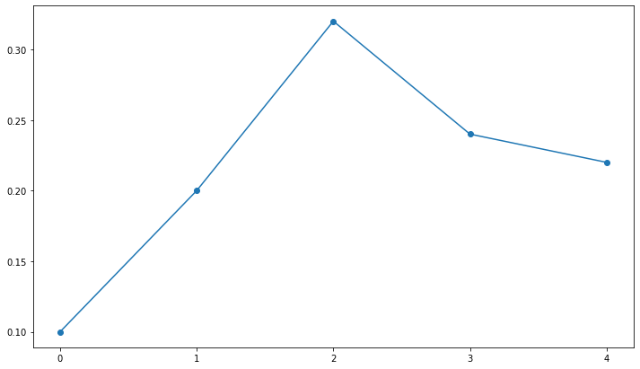

```python
plot_bandit(bandit_instance)
```

## Sequential algorithms

```python
# Constantly play the same arm
class Constant(SequentiAlg):
    def __init__(self, bandit, name="Constant", params={'init': 1, 'choice': 0 }):
        SequentiAlg.__init__(self, bandit, name=name, params=params)
        self.choice = params['choice']
        self.name = f"{self.name} (arm {self.choice})"
        assert self.choice < bandit.nbr_arms, f"'choice' ({self.choice}) should be one of\
the arms indices (<{bandit.nbr_arms})"

    def compute_indices(self):
        self.indices[self.choice] = 0

# Non-optimized Explore Then Commit strategy
class Etc(SequentiAlg):
    def __init__(self, bandit, name="ETC", params={'init': 0, 'exploration': 200 }):
        SequentiAlg.__init__(self, bandit, name=name, params=params)
        self.exploration = params['exploration']

    def compute_indices(self):
        if self.time <= self.exploration:
            # probably faster computation is possible
            self.indices = np.random.rand(self.bandit.nbr_arms)
        else:
            self.indices = self.means

    def choose_an_arm(self):
        return randamax(self.indices)
```

```python
# Set of means
means = [0.2, 0.5, 0., 0.05, 0.3, 0.4]
# Create a bandit problem
bandit = NormalBandit(means)
# Create sequential algorithms
seqalg1 = Constant(bandit) # Constantly play the same arm
seqalg2 = SequentiAlg(bandit, name="Random") # Sequentially choose an arm using a uniform distribution on the set of arms
seqalg3 = Constant(bandit, params = {'init': 1, 'choice': 3}) # Constantly play the same arm
seqalg4 = Etc(bandit) # Explore Then Commit strategy
```

```python
print(seqalg4)
```

```
ETC algorithm - time step = 0
  Normal (mean=0.200, std=1.000) : est. mean = 0.000 - nbr. pulls = 0
  Normal (mean=0.500, std=1.000) : est. mean = 0.000 - nbr. pulls = 0
  Normal (mean=0.000, std=1.000) : est. mean = 0.000 - nbr. pulls = 0
  Normal (mean=0.050, std=1.000) : est. mean = 0.000 - nbr. pulls = 0
  Normal (mean=0.300, std=1.000) : est. mean = 0.000 - nbr. pulls = 0
  Normal (mean=0.400, std=1.000) : est. mean = 0.000 - nbr. pulls = 0
```

```python
test_experiment = Experiment([seqalg1, seqalg2, seqalg3, seqalg4], bandit,
                             statistics={'mean':True, 'std':True, 'quantile':True, 'pulls':False},
                             complexity=False)
```

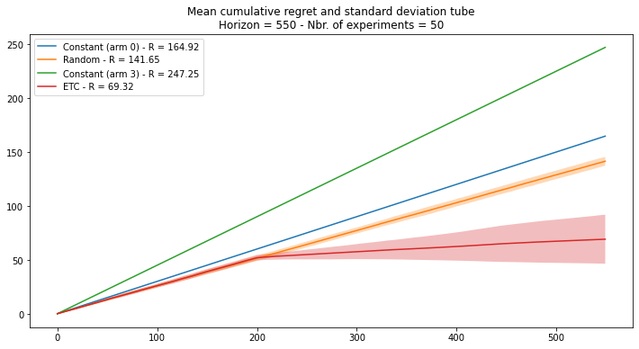

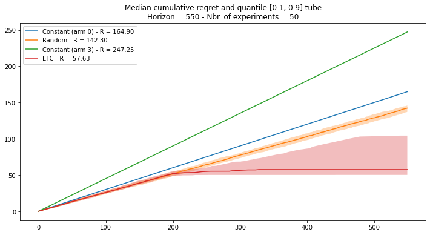

```python
test_experiment.run(50, 550)
test_experiment.plot()
```

```python
print(seqalg4)
```

```
ETC algorithm - time step = 550
  Normal (mean=0.200, std=1.000) : est. mean = 0.184 - nbr. pulls = 26
  Normal (mean=0.500, std=1.000) : est. mean = 0.317 - nbr. pulls = 30
  Normal (mean=0.000, std=1.000) : est. mean = -0.077 - nbr. pulls = 39
  Normal (mean=0.050, std=1.000) : est. mean = 0.396 - nbr. pulls = 87
  Normal (mean=0.300, std=1.000) : est. mean = 0.403 - nbr. pulls = 244
  Normal (mean=0.400, std=1.000) : est. mean = 0.395 - nbr. pulls = 124
```

## Part 1 - UCB algorithm

#### Question 1

Using the `SequentiAlg` class, implement the **UCB** algorithm.

#### Question 2

Using the `Experiment` class, run experiments on (at least) two bandit problems of your choice.

#### Question 3

Comment the plots (suboptimality gaps, number of arms...).

## Part 2 - IMED algorithms

On a Gaussian bandit instance, the *Lai and Robbins lower bound* tells us that the regret is **asymptotically** no smaller than

$$\left(\sum_{a \in \mathcal{A}} \frac{\Delta_a}{\mathrm{KL}(\mu_a,\mu_*)}\right) \log(T),$$

where $\mathrm{KL}(\mu_a,\mu_*)$ is the KL-divergence between the Gaussian distribution of mean $\mu_a$ and the Gaussian distribution of mean $\mu_*$ (unitary variances). The constant in front of the $\log(T)$ may be called the **complexity** of the bandit problem.

For all arm $a \in \mathcal{A}$, for all time step $t \geq 1$, the empirical mean of arm $a$ at time step $t$ is $$\hat \mu_a(t) = \dfrac{1}{N_a(t)} \sum\limits_{s = 1}^t \mathbb{1}_{\{a_s = a\}}X_s, \text{ if } N_a(t) > 0,\ 0 \text{ otherwise}, $$ where $N_a(t) = \sum\limits_{ s=1}^t \mathbb{1}_{\{ a_s = a\}}$ is the number of pulls of arm $a$ at time $t$. We write $\hat \mu_*(t) = \max\limits_{a \in \mathcal{A}}\hat\mu_a(t)$.

#### IMED strategy - Honda and Takemura (2011)

For an arm $a \in \mathcal{A}$ and a time step $t\geq 1$, the IMED index is defined as follows: $$ I_a(t) = N_a(t)\,\mathrm{KL}\!\left(\hat\mu_a(t),\hat \mu_*(t)\right)+ \log\!\left(N_a(t)\right) \,. $$

This quantity can be seen as a transportation cost for “moving" a sub-optimal arm to an optimal one, plus exploration terms (the logarithms of the numbers of pulls). When an optimal arm is considered, the transportation cost is null and it remains only the exploration part. Note that, as stated in Honda and Takemura (2011), $I_a(t)$ is an index in a weak sense since it cannot be determined only by samples from the arm $a$ but also uses empirical means of current optimal arms.

IMED is the strategy that consists in pulling an arm with minimal index at each time step: $$ a_{t+1} = \arg\!\min_{a \in \mathcal{A}}I_a(t) \,.$$

#### Bonus Question

Derive the formula of the Kullback-Leibler divergences between two Gaussian distributions.

#### Implementation of the IMED strategy

```python
class IMED(SequentiAlg):
    def __init__(self, bandit, name="IMED", params={'init': -np.inf, 'kl':klGaussian}):
        SequentiAlg.__init__(self, bandit, name=name, params=params)
        self.kl = params['kl']

    def compute_indices(self):
        max_mean = np.max(self.means)
        if self.all_selected:
            self.indices = self.nbr_pulls*self.kl(self.means, max_mean) + np.log(self.nbr_pulls)
        else:
            for arm in np.where(self.nbr_pulls != 0)[0]:
                self.indices[arm] = self.nbr_pulls[arm]*self.kl(self.means[arm], max_mean) \
                + np.log(self.nbr_pulls[arm])
```

#### Experiment the IMED strategy

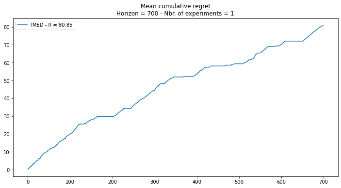

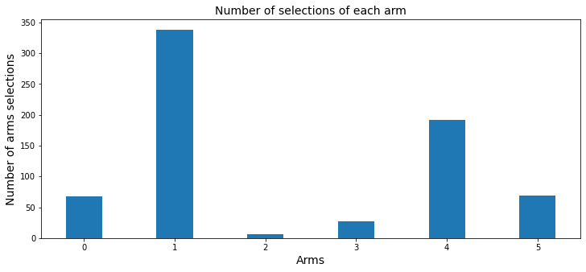

```python
horizon = 700
agent = IMED(bandit)
experiment_imed = Experiment([agent], bandit,
                             statistics={'mean':True, 'std':False, 'quantile':False, 'pulls':False},
                             complexity=False)

experiment_imed.run(1, horizon)
experiment_imed.plot()
# Visualize results (on one run)

# Histogram of the number of arms selections
plt.figure(figsize=(12,5))
plt.xlabel("Arms", fontsize=14)
plt.ylabel("Number of arms selections", fontsize=14)
plt.bar(range(bandit.nbr_arms), agent.nbr_pulls, width=0.4, tick_label=[str(i) for i in range(bandit.nbr_arms)])
plt.title("Number of selections of each arm", fontsize=14)
plt.show()
```

#### Compare strategies

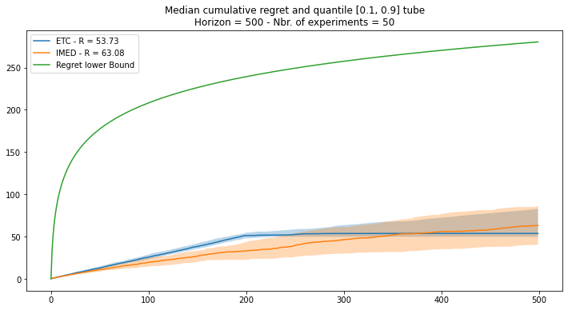

```python
nbr_exp = 50
horizon = 500
etc = Etc(bandit) # Explore Then Commit strategy
imed = IMED(bandit) # IMED strategy
experiment = Experiment([etc, imed], bandit,
                        statistics={'mean':False, 'std':False, 'quantile':True, 'pulls':False},
                        complexity=True)
experiment.run(nbr_exp, horizon)
experiment.plot()
```

## Part 2 - Unimodal bandits

We assume that $\mathcal{A} = \left\{0, \dots, A-1\right\}, A \geq 1$, and $ \mu : \begin{cases} \mathcal{A} & \to \mathbb{R} \\ a &\mapsto \mu_a \end{cases} $ is unimodal. That is, there exists $ a_* \!\in\! \mathcal{A}$ such that $\mu_{[\![0,a_*]\!]} $ is increasing and $ \mu_{[\![ a_*, A]\!]} $ is decreasing. It is further assumed that for each arm $a$, $ \nu_{a} $ is a Gaussian distribution $ \mathcal{N}(\mu_a,1) $ , where $ \mu_a \in \mathbb{R} $ is the mean of the distribution $\nu_{a}$. We denote the structured set of Gaussian unimodal bandit distributions by $$\mathcal{D}_{\text{unimodal}} = \bigg\{\nu = (\nu_a)_{a \in \mathcal{A}}:\ \forall a \!\in\! \mathcal{A},\ \nu_a \sim \mathcal{N}(\mu_a,1) \text{ with } \mu_a \!\in\! \mathbb{R}\text{ and }\mu \text{ is unimodal}\bigg\}\,.$$

On a Gaussian unimodal bandit instance, the Lai and Robbins lower bound tells us that the regret is **asymptotically** no smaller than

$$\left(\sum_{a \in \mathcal{V}_{a_*}} \frac{\Delta_a}{\mathrm{KL}(\mu_a,\mu_*)}\right) \log(T),$$

where $\mathcal{V}_{a_*} = \{a_* - 1, a_* + 1\}\cap\mathcal{A}$ and $\mathrm{KL}(\mu_a,\mu_*)$ is the KL-divergence between the Gaussian distribution of mean $\mu_a$ and the Gaussian distribution of mean $\mu_*$ (variances equal to $1$). The constant in front of the $\log(T)$ may be called the **unimodal complexity** of the bandit problem.

### 1) Computing regret lower bound for a unimodal bandit instance

#### Question 4

Write a function that computes the complexity of a unimodal Gaussian bandit instance.

#### Question 5

Write a function that generates at random a unimodal Gaussian bandit instance.

#### Question 6

On a unimodal Gaussian bandit instance $\nu $ of your choice, add the theoretical lower bound $t \mapsto C_{\text{unimodal}}(\nu) \log(t)$ where $C_{\text{unimodal}}(\nu)$ is the unimodal complexity of a unimodal bandit problem to the regret curve of IMED.

Add a plot with experiments of your choice using the previous algorithms.

### 2) IMED for Unimodal Bandit

For an arm $a \in \mathcal{A}$ and a time step $t\geq 1$, the IMED4UB index is defined as follows: $$ I_a(t) = N_a(t)\,\mathrm{KL}\!\left(\hat\mu_a(t),\hat \mu_*(t)\right)+ \log\!\left(N_a(t)\right) \,. $$

IMED4UB is the strategy that consists in pulling an arm in the neighbourhood of the current optimal arm (also called leader arm, the one with the largest empirical mean) with minimal index at each time step: $$ a_{t+1} = \arg\!\min_{a \in \mathcal{V}_{\hat a_*(t)}\cup \hat a_*(t)}I_a(t) \,.$$

#### Question 7

Write a class that provides an IMED type strategy for unimodal bandit inspired from the regret lower bound for unimodal structure.

Experiment like it was done in **part 1**. You can comment and add experiments of your choice.

## Part 3 - Lipschitz bandits

We assume that $\mathcal{A} = \left\{0, \dots, A-1\right\}, A \geq 1$, and $ \mu : \begin{cases} \mathcal{A} & \to \mathbb{R} \\ a &\mapsto \mu_a \end{cases} $ is $k$-Lipschitz, where is $k$ is assumed to be known. That is, for all $ a, a' \!\in\! \mathcal{A}$, $|\mu_a - \mu_{a'}| \leq k\!\times\! |a - a'|$. It is further assumed that for each arm $a$, $ \nu_{a} $ is a Gaussian distribution $ \mathcal{N}(\mu_a,1) $ , where $ \mu_a \in \mathbb{R} $ is the mean of the distribution $\nu_{a}$. We denote the structured set of Gaussian $k$-Lipschitz bandit distributions by $$\mathcal{D}_{k\text{-Lip}} = \bigg\{\nu = (\nu_a)_{a \in \mathcal{A}}:\ \forall a \!\in\! \mathcal{A},\ \nu_a \sim \mathcal{N}(\mu_a,1) \text{ with } \mu_a \!\in\! \mathbb{R}\text{ and }\mu \text{ is } k\text{-Lipschitz}\bigg\}\,.$$

On a Gaussian $k$-Lipschitz bandit instance, the lower bound specifies that the numbers of pulls satisfy **asymptotically** the following inequalities

$$\forall a \in \mathcal{A}, \quad \sum_{a' \in \mathcal{V}_{a}} \mathrm{KL}\!\left(\mu_{a'},\,\mu_*\!-\!k|a \!-\! a'|\right)\,N_{a'}(T) \geq \log(T)\,,$$

where $\mathcal{V}_{a} = \big\{a'\!\in\!\mathcal{A}\!: \mu_{a'}\!<\! \mu_*\!-\!k|a \!-\! a'|\big\}$ and $\mathrm{KL}(\mu,\mu')$ is the KL-divergence between the Gaussian distribution of mean $\mu$ and the Gaussian distribution of mean $\mu'$ (unitary variances). The constant $C_{k\text{-Lip}}(\nu)$ resulting from the following linear programming problem may be called the **Lipschitz complexity** of the bandit problem: $$ C_{k\text{-Lip}}(\nu) = \min \bigg\{\sum\limits_{a \in \mathcal{A}} (\mu_*-\mu_a)\,n_{a}:\ n \in \mathbb{R}_+^{\mathcal{A}} \text{ s.t. } \forall a \in \mathcal{A},\sum_{a' \in \mathcal{V}_{a}} \mathrm{KL}\!\left(\mu_{a'},\,\mu_*\!-\!k|a \!-\! a'|\right)\,n_{a'} \geq 1\bigg\}\,. $$

### 1) Computing regret lower bound for a k-Lipschitz bandit instance

#### Question 8

Write a function that computes the complexity of a $k$-Lipschitz bandit instance.

#### Question 9

Write a function that generates at random a Lipschitz Gaussian bandit instance.

#### Question 10

On a $k$-Lipschitz Gaussian bandit instance $\nu $ of your choice, add the theoretical lower bound $t \mapsto C_{k-\text{Lip}}(\nu) \log(t)$ where $C_{k\text{-Lip}}(\nu)$ is the lipschitz complexity of a lipschitz bandit problem to the regret curve of IMED.

### 2) IMED for Lipschitz Bandit

For an arm $a \in \mathcal{A}$ and a time step $t\geq 1$, the IMED4LB index is defined as follows: $$ I_a(t) = \sum\limits_{a ' \in \hat{\mathcal{V}}_{a}(t)}N_{a'}(t)\,\mathrm{KL}\!\left(\hat\mu_{a'}(t),\hat \mu_*(t) - k |a - a'|\right)+ \log\!\left(N_{a'}(t)\right) \,, $$ where $\hat{\mathcal{V}}_{a}(t) = \big\{a'\!\in\!\mathcal{A}\!: \hat\mu_{a'}(t)\!\leq\! \hat\mu_*(t)\!-\!k|a \!-\! a'|\big\}$.

IMED4LB is the strategy that consists in pulling an arm with minimal index at each time step: $$ a_{t+1} = \arg\!\min_{a \in \mathcal{V}_{\hat a_*(t)}}I_a(t) \,.$$

#### Question 11

Write a class that provides an IMED type strategy for Lipschitz bandit inspired from the lower bounds on the number of pulls for Lipschitz structure.

Experiment like it was done in **part 1**. You can comment and add experiments of your choice.

## Part 4 - Linear bandits

Let us consider the discretisation $\mathcal{A} = \left\{0, \dots, A-1\right\}, A \geq 1$ of the space $ \mathcal{X} = \bigg\{x_a=\dfrac{a}{A}\ ,a\!\in\!\mathcal{A} \bigg\} \subset [0,1]$. Let us consider the parameter space $\Theta = \mathcal{B}(O,1)\subset\mathbb{R}^d$, $d = 2p+1$, $p\geq 1$, and the related function space $\mathcal{F}_{\Theta} = \bigg\{ f_\theta: x\in \mathcal{X} \mapsto \theta^{\text{T}}\phi(x)\ , \theta \in \Theta \bigg\}$, where $ \forall x\in\mathcal{X}, \phi(x) = \!\left(1, \cos(2\pi x),\sin(2\pi x),\dots,\cos(2\pi p x), \sin(2\pi p x)\right) $. It is further assumed that for all parameter $\theta\in\Theta$, for all arm $a\in\mathcal{A}$, $ \nu_{a}(\theta) $ is a Gaussian distribution $ \mathcal{N}(\mu_a(\theta),1) $ , where $ \mu_a(\theta) = f_\theta(x_a) $ is the mean of the distribution $\nu_{a}(\theta)$. We denote the structured set of Linear bandit distributions by $$\mathcal{D}_{\Theta} = \bigg\{\nu(\theta) = \left(\nu_a(\theta)\right)_{a \in \mathcal{A}}\ , \theta\in\Theta \bigg\}\,.$$

#### Question 12

Write a function that generates at random a Linear Gaussian bandit instance.

### 1) The Linear UCB algorithm

#### Question 13

Implement the linear UCB algorithm: LinearUCB($\lambda=1$, $\delta= 0.05$ , $\sigma^2 = 1$).

### 2) The Linear IMED algorithm

For an arm $a \in \mathcal{A}$ and a time step $t\geq 1$, the LinearIMED index is defined as follows: $$ I_a(t) = N_a^{\text{eff}}(t)\,\dfrac{\left(\max_{x \in \mathcal{X}}\hat f_{t,\lambda}(x) - \hat f_{t,\lambda}(x_a)\right)^2}{2} + \log\!\left(N_a^{\text{eff}}(t)\right) \,, $$ where $ \hat f_{t,\lambda} $ is the current estimate of $f$ and $N_a^{\text{eff}}(t) = \!\left( |\!| \phi(x_a) |\!|_{G_t^{-1}}^2 \right)^{-1} $, the effective number of pull of arms $a$. $ G_t$ is the current Gramm matrix (used for the regression).

LinearIMED is the strategy that consists in pulling an arm with minimal index at each time step: $$ a_{t+1} = \arg\!\min_{a \in \mathcal{A}}I_a(t) \,.$$

#### Question 14

Write a class that provides an IMED type strategy for linear bandit inspired from the lower bounds on the number of pulls for Linear structure.

#### Question 15

Compare LinearUCB and LinearIMED.